# Basic Eye Gaze (study2children)

Adam Stone, PhD

01-25-2018

# Starting Out

We’ve cleaned up the data in 01importclean. So we’re importing it here. Let’s grab histograms of our kids and groups.

```r
# Libraries
library(tidyverse)
library(feather)
library(scales)
library(stringr)
library(viridis)
library(lme4)
library(lmerTest)
library(RColorBrewer)
#library(cowplot)
# Import data that's been cleaned up from 01importclean
data <- read_feather("cleanedchildeyedata.feather")
participants <- data %>%
  select(participant, gender, language, age) %>%
  distinct()
participants_n <- participants %>%
  count(gender, language) %>%
  spread(gender, n)
participants_age <- participants %>%
  group_by(language) %>%
  summarise(age_m = round(mean(age), 1),
            age_sd = round(sd(age), 1),
            age_min = range(age)[1],
            age_max = range(age)[2]) %>%
  mutate(age_range = paste(age_min, age_max, sep = " - ")) %>%
  select(-age_min, -age_max) %>%
  mutate(age_mean = paste(age_m, age_sd, sep = "±")) %>%
  select(-age_m, -age_sd) %>%
  select(language, age_mean, age_range)
left_join(participants_n, participants_age, by = "language")
```

| language | Female | Male | age_mean | age_range |
| --- | --- | --- | --- | --- |
| english | 8 | 7 | 5±1.4 | 2.7 - 8.3 |
| sign | 10 | 11 | 5.2±2.1 | 2.13 - 10.5 |

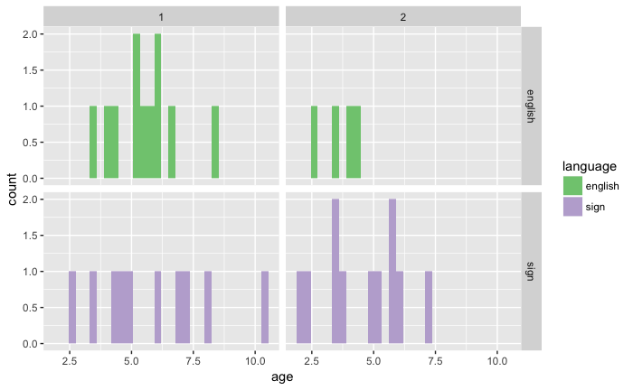

```r
data_ages <- data %>%
  select(participant, language, age, group) %>%
  distinct()
ggplot(data_ages, aes(x = age, fill = language)) + geom_histogram() + facet_grid(language ~ group) + scale_fill_brewer(palette = "Accent")
```

First, let’s do boxplots of each AOI across all stories and kids, grouping for forward vs. reversed.

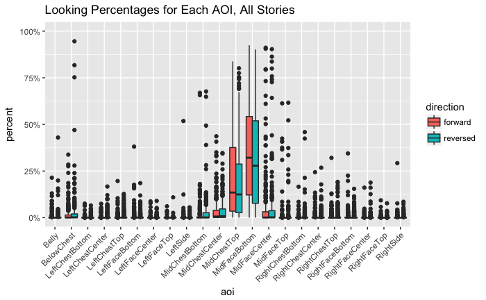

```r
# Boxplot!
ggplot(data, aes(x = aoi, y = percent, fill = direction)) +
  geom_boxplot() + theme(axis.text.x = element_text(angle=45, hjust = 1)) +
  ggtitle("Looking Percentages for Each AOI, All Stories") +
  scale_y_continuous(labels = scales::percent, limits = c(0,1))
```

Looks like by far most of the activity is along the Mid** AOIs. Let’s look closer.

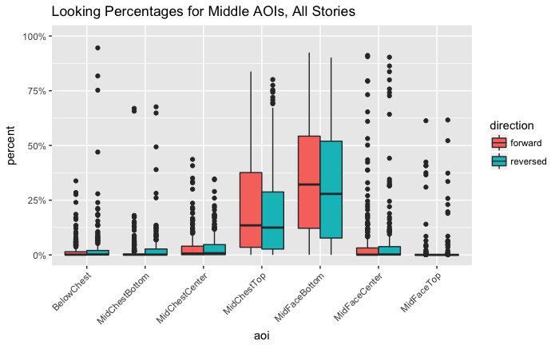

```r
data_mid <- data %>%
  filter(str_detect(aoi,"Mid") | aoi == "BelowChest")
ggplot(data_mid, aes(x = aoi, y = percent, fill = direction)) +
  geom_boxplot() + theme(axis.text.x = element_text(angle=45, hjust = 1)) +
  ggtitle("Looking Percentages for Middle AOIs, All Stories") +
  scale_y_continuous(labels = scales::percent, limits = c(0,1))
```

As a preliminary analysis I’m going to just look at MidChestTop and MidFaceBottom. Are there differences based on direction, group, or age for either AOI?

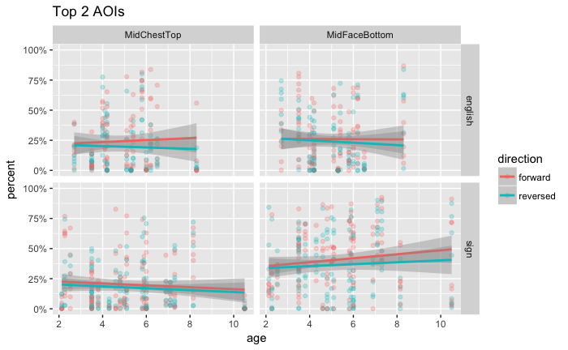

```r
data_mid %>%
  filter(aoi == "MidChestTop" | aoi == "MidFaceBottom") %>%
  ggplot(aes(x = age, y = percent, color = direction)) + geom_point(alpha = 0.25) +
  geom_smooth(method = "lm") + facet_grid(language ~ aoi) +
  scale_y_continuous(labels = scales::percent, limits = c(0,1)) +
  ggtitle("Top 2 AOIs")
```

I am not observing big differences for directin. But I sort of notice that CODAs show increased looking at MidFaceBottom as they get older, while English kids don’t (and actually show a downward trajectory).

What if we defined a Face-Chest Ratio (FCR) such that:

1. MidFaceCenter, MidFaceBottom = Face
2. MidChestTop, MidChestCenter, MidChestBottom, BelowChest = Chest
3. FCR = face - chest / face + chest

Let’s try that. Let’s also try only MidFaceBottom vs. MidChestTop too, and call that MFCR (for middle of middle).

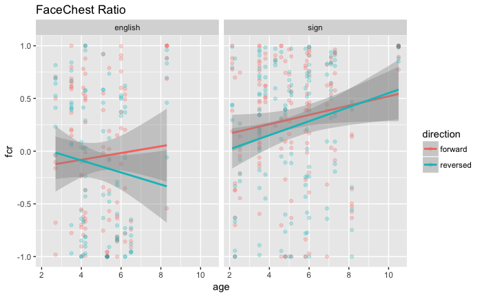

```r
data_mid <- data_mid %>%
  select(-secs, -hits) %>%
  spread(aoi,percent) %>%
  group_by(participant, trial) %>%
  mutate(face = sum(MidFaceCenter, MidFaceBottom, na.rm = TRUE),
         chest = sum(MidChestTop, MidChestCenter, MidChestBottom, BelowChest, na.rm = TRUE),
         fcr = (face - chest) / (face + chest),
         mfcr = (MidFaceBottom - MidChestTop) / (MidFaceBottom + MidChestTop))
ggplot(data_mid, aes(x = age, y = fcr, color = direction)) + geom_point(alpha = 0.25) +
  geom_smooth(method = "lm") + facet_wrap("language") + ggtitle("FaceChest Ratio")
```

Let’s also check out MFCR (a stricter ratio). Almost the same thing.

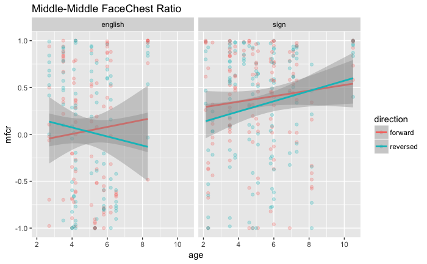

```r
ggplot(data_mid, aes(x = age, y = mfcr, color = direction)) + geom_point(alpha = 0.25) +
  geom_smooth(method = "lm") + facet_wrap("language") + ggtitle("Middle-Middle FaceChest Ratio")
```

# Heat Maps

So this is rad! Such obvious group differences should also be reflected in a heat map that is collapsed across age and direction. And the heat map below shows that CODAs really focus on the MidFaceBottom AOI, while English-exposed children are a bit more spread out, looking much more at the chest.

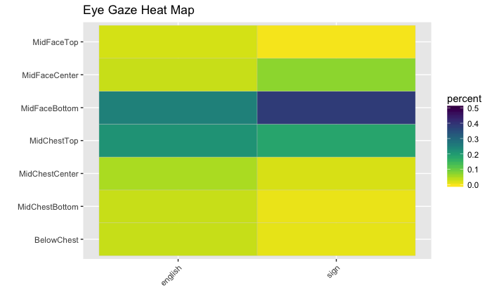

```r
data_mid_heat <- data_mid %>%
  ungroup() %>%
  select(-face, -chest, -fcr, -mfcr) %>%
  gather(aoi, percent, BelowChest:MidFaceTop) %>%
  group_by(language, participant, direction, aoi) %>%
  summarise(percent = mean(percent, na.rm = TRUE)) %>%
  group_by(language, direction, aoi) %>%
  summarise(percent = mean(percent, na.rm = TRUE)) %>%
  group_by(language, aoi) %>%
  summarise(percent = mean(percent, na.rm = TRUE)) %>%
  mutate(aoi = factor(aoi, levels = c("BelowChest", "MidChestBottom", "MidChestCenter", "MidChestTop",
                                      "MidFaceBottom", "MidFaceCenter", "MidFaceTop")))
ggplot(data_mid_heat, aes(x = language, y = aoi)) +
  geom_tile(aes(fill=percent),color="lightgray",na.rm=TRUE) +
  scale_fill_viridis(option = "viridis", direction=-1, limits = c(0,.5)) +
  theme(axis.text.x=element_text(angle=45,hjust=1)) +
  ylab("") + xlab("") + ggtitle("Eye Gaze Heat Map")
```

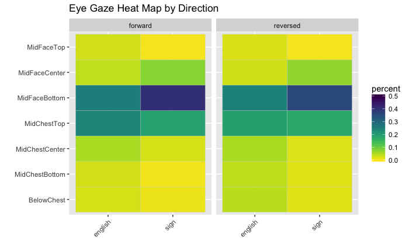

```r
data_mid_heat <- data_mid %>%
  ungroup() %>%
  select(-face, -chest, -fcr, -mfcr) %>%
  gather(aoi, percent, BelowChest:MidFaceTop) %>%
  group_by(language, participant, direction, aoi) %>%
  summarise(percent = mean(percent, na.rm = TRUE)) %>%
  group_by(language, direction, aoi) %>%
  summarise(percent = mean(percent, na.rm = TRUE)) %>%
  mutate(aoi = factor(aoi, levels = c("BelowChest", "MidChestBottom", "MidChestCenter", "MidChestTop",
                                      "MidFaceBottom", "MidFaceCenter", "MidFaceTop")))
ggplot(data_mid_heat, aes(x = language, y = aoi)) +
  geom_tile(aes(fill=percent),color="lightgray",na.rm=TRUE) +
  scale_fill_viridis(option = "viridis", direction=-1, limits = c(0,.5)) +
  theme(axis.text.x=element_text(angle=45,hjust=1)) +
  ylab("") + xlab("") + ggtitle("Eye Gaze Heat Map by Direction") + facet_wrap("direction")
```

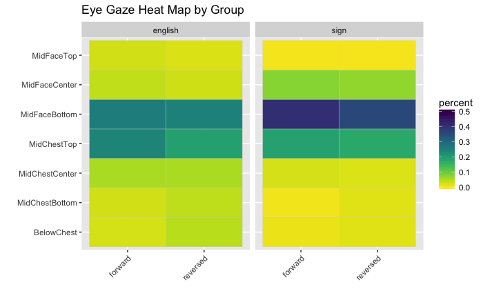

```r
ggplot(data_mid_heat, aes(x = direction, y = aoi)) +
  geom_tile(aes(fill=percent),color="lightgray",na.rm=TRUE) +
  scale_fill_viridis(option = "viridis", direction=-1, limits = c(0,.5)) +
  theme(axis.text.x=element_text(angle=45,hjust=1)) +
  ylab("") + xlab("") + ggtitle("Eye Gaze Heat Map by Group") + facet_wrap("language")
```

# Statistical Testing of FCR/mFCR

Now that we’ve found something interesting with FCR and mFCR, let’s see if it holds up in stats modeling.

## Language, Direction, & Age Predictors

```r
fcr_lmm <- lmer(fcr ~ age + language * direction + (1|story) + (1|participant), data = data_mid)
fcr_lmm_children <- fcr_lmm
summary(fcr_lmm)
```

```
Linear mixed model fit by REML t-tests use Satterthwaite approximations to degrees of freedom [lmerMod]
Formula: fcr ~ age + language * direction + (1 | story) + (1 | participant)
   Data: data_mid

REML criterion at convergence: 759.4

Scaled residuals:
     Min       1Q   Median       3Q      Max
-3.09679 -0.54281  0.04917  0.66075  2.99284

Random effects:
 Groups      Name        Variance Std.Dev.
 participant (Intercept) 0.18416  0.4291
 story       (Intercept) 0.01318  0.1148
 Residual                0.22088  0.4700
Number of obs: 487, groups:  participant, 36; story, 8

Fixed effects:
                                Estimate Std. Error        df t value Pr(>|t|)
(Intercept)                     -0.21828    0.24302  36.10000  -0.898   0.3750
age                              0.03186    0.04151  33.00000   0.768   0.4482
languagesign                     0.38121    0.15814  39.00000   2.411   0.0207 *
directionreversed               -0.04936    0.06823 448.50000  -0.723   0.4698
languagesign:directionreversed  -0.05863    0.08927 450.10000  -0.657   0.5117
---
Signif. codes:  0 ‘***’ 0.001 ‘**’ 0.01 ‘*’ 0.05 ‘.’ 0.1 ‘ ’ 1

Correlation of Fixed Effects:
            (Intr) age    lnggsg drctnr
age         -0.852
languagesgn -0.335 -0.052
dirctnrvrsd -0.143  0.001  0.220
lnggsgn:drc  0.111 -0.002 -0.282 -0.773
```

Let’s repeat the LMM with outcome mFCR.

```r
mfcr_lmm <- lmer(mfcr ~ age + language * direction + (1|story) + (1|participant), data = data_mid)
summary(mfcr_lmm)
```

```
Linear mixed model fit by REML t-tests use Satterthwaite approximations to degrees of freedom [lmerMod]
Formula: mfcr ~ age + language * direction + (1 | story) + (1 | participant)
   Data: data_mid

REML criterion at convergence: 754.7

Scaled residuals:
    Min      1Q  Median      3Q     Max
-3.1651 -0.5190  0.0802  0.6210  2.8813

Random effects:
 Groups      Name        Variance Std.Dev.
 participant (Intercept) 0.185499 0.4307
 story       (Intercept) 0.007744 0.0880
 Residual                0.229265 0.4788
Number of obs: 474, groups:  participant, 36; story, 8

Fixed effects:
                                 Estimate Std. Error         df t value Pr(>|t|)
(Intercept)                     -0.086289   0.242874  35.000000  -0.355   0.7245
age                              0.021945   0.041716  32.600000   0.526   0.6024
languagesign                     0.374252   0.159159  38.700000   2.351   0.0239 *
directionreversed                0.001059   0.070520 431.300000   0.015   0.9880
languagesign:directionreversed  -0.102260   0.091984 435.400000  -1.112   0.2669
---
Signif. codes:  0 ‘***’ 0.001 ‘**’ 0.01 ‘*’ 0.05 ‘.’ 0.1 ‘ ’ 1

Correlation of Fixed Effects:
            (Intr) age    lnggsg drctnr
age         -0.857
languagesgn -0.337 -0.052
dirctnrvrsd -0.143  0.002  0.219
lnggsgn:drc  0.112 -0.003 -0.283 -0.773
```

## Direction & Language Predictors

```r
fcr_lmm_noage <- lmer(fcr ~ direction * language + (1|story) + (1|participant), data = data_mid)
summary(fcr_lmm_noage)
```

```
Linear mixed model fit by REML t-tests use Satterthwaite approximations to degrees of freedom [lmerMod]
Formula: fcr ~ direction * language + (1 | story) + (1 | participant)
   Data: data_mid

REML criterion at convergence: 755.5

Scaled residuals:
    Min      1Q  Median      3Q     Max
-3.0979 -0.5425  0.0463  0.6606  2.9749

Random effects:
 Groups      Name        Variance Std.Dev.
 participant (Intercept) 0.18190  0.4265
 story       (Intercept) 0.01315  0.1147
 Residual                0.22087  0.4700
Number of obs: 487, groups:  participant, 36; story, 8

Fixed effects:
                                Estimate Std. Error        df t value Pr(>|t|)
(Intercept)                     -0.05936    0.12667  44.50000  -0.469    0.642
directionreversed               -0.04946    0.06823 448.60000  -0.725    0.469
languagesign                     0.38743    0.15711  40.30000   2.466    0.018 *
directionreversed:languagesign  -0.05837    0.08927 450.10000  -0.654    0.514
---
Signif. codes:  0 ‘***’ 0.001 ‘**’ 0.01 ‘*’ 0.05 ‘.’ 0.1 ‘ ’ 1

Correlation of Fixed Effects:
            (Intr) drctnr lnggsg
dirctnrvrsd -0.272
languagesgn -0.724  0.222
drctnrvrsd:  0.210 -0.773 -0.284
```

The mFCR LMM gives us similar results.

```r
mfcr_lmm_noage <- lmer(mfcr ~ direction * language + (1|story) + (1|participant), data = data_mid)
summary(mfcr_lmm_noage)
```

```
Linear mixed model fit by REML t-tests use Satterthwaite approximations to degrees of freedom [lmerMod]
Formula: mfcr ~ direction * language + (1 | story) + (1 | participant)
   Data: data_mid

REML criterion at convergence: 750.5

Scaled residuals:
    Min      1Q  Median      3Q     Max
-3.1655 -0.5241  0.0732  0.6182  2.8670

Random effects:
 Groups      Name        Variance Std.Dev.
 participant (Intercept) 0.181278 0.42577
 story       (Intercept) 0.007729 0.08791
 Residual                0.229260 0.47881
Number of obs: 474, groups:  participant, 36; story, 8

Fixed effects:
                                 Estimate Std. Error         df t value Pr(>|t|)
(Intercept)                     2.321e-02  1.242e-01  4.280e+01   0.187   0.8526
directionreversed               9.579e-04  7.052e-02  4.313e+02   0.014   0.9892
languagesign                    3.785e-01  1.574e-01  4.010e+01   2.404   0.0209 *
directionreversed:languagesign -1.020e-01  9.198e-02  4.355e+02  -1.109   0.2679
---
Signif. codes:  0 ‘***’ 0.001 ‘**’ 0.01 ‘*’ 0.05 ‘.’ 0.1 ‘ ’ 1

Correlation of Fixed Effects:
            (Intr) drctnr lnggsg
dirctnrvrsd -0.277
languagesgn -0.740  0.221
drctnrvrsd:  0.214 -0.773 -0.286
```

## Language as only predictor

What if only language? I want to look at forward v. reversed separately next.

```r
fcr_lmm_langonly <- lmer(fcr ~  language + (1|story) + (1|participant) + (1|direction), data = data_mid)
summary(fcr_lmm_langonly)
```

```
Linear mixed model fit by REML t-tests use Satterthwaite approximations to degrees of freedom [lmerMod]
Formula: fcr ~ language + (1 | story) + (1 | participant) + (1 | direction)
   Data: data_mid

REML criterion at convergence: 750.8

Scaled residuals:
     Min       1Q   Median       3Q      Max
-3.15058 -0.52075  0.05729  0.64103  2.93023

Random effects:
 Groups      Name        Variance Std.Dev.
 participant (Intercept) 0.181184 0.42566
 story       (Intercept) 0.013045 0.11422
 direction   (Intercept) 0.002585 0.05084
 Residual                0.220674 0.46976
Number of obs: 487, groups:  participant, 36; story, 8; direction, 2

Fixed effects:
             Estimate Std. Error       df t value Pr(>|t|)
(Intercept)  -0.08404    0.12685 29.36000  -0.663   0.5128
languagesign  0.35855    0.15035 34.12000   2.385   0.0228 *
---
Signif. codes:  0 ‘***’ 0.001 ‘**’ 0.01 ‘*’ 0.05 ‘.’ 0.1 ‘ ’ 1

Correlation of Fixed Effects:
            (Intr)
languagesgn -0.690
```

Forward only.

```r
fcr_lmm_langonly_f <- lmer(fcr ~  language + (1|story) + (1|participant), data = filter(data_mid,direction=="forward"))
summary(fcr_lmm_langonly_f)
```

```
Linear mixed model fit by REML t-tests use Satterthwaite approximations to degrees of freedom [lmerMod]
Formula: fcr ~ language + (1 | story) + (1 | participant)
   Data: filter(data_mid, direction == "forward")

REML criterion at convergence: 371.3

Scaled residuals:
     Min       1Q   Median       3Q      Max
-2.87768 -0.47314  0.01083  0.61988  2.21636

Random effects:
 Groups      Name        Variance Std.Dev.
 participant (Intercept) 0.1872   0.4327
 story       (Intercept) 0.0396   0.1990
 Residual                0.1850   0.4301
Number of obs: 245, groups:  participant, 36; story, 8

Fixed effects:
             Estimate Std. Error      df t value Pr(>|t|)
(Intercept)   -0.0530     0.1411 32.5900  -0.376   0.7097
languagesign   0.3719     0.1593 34.9300   2.334   0.0255 *
---
Signif. codes:  0 ‘***’ 0.001 ‘**’ 0.01 ‘*’ 0.05 ‘.’ 0.1 ‘ ’ 1

Correlation of Fixed Effects:
            (Intr)
languagesgn -0.669
```

Reversed only.

```r
fcr_lmm_langonly_r <- lmer(fcr ~  language + (1|story) + (1|participant), data = filter(data_mid,direction=="reversed"))
summary(fcr_lmm_langonly_r)
```

```
Linear mixed model fit by REML t-tests use Satterthwaite approximations to degrees of freedom [lmerMod]
Formula: fcr ~ language + (1 | story) + (1 | participant)
   Data: filter(data_mid, direction == "reversed")

REML criterion at convergence: 420.6

Scaled residuals:
     Min       1Q   Median       3Q      Max
-2.51358 -0.55000  0.07461  0.70861  2.41163

Random effects:
 Groups      Name        Variance Std.Dev.
 participant (Intercept) 0.16912  0.4112
 story       (Intercept) 0.01338  0.1157
 Residual                0.24879  0.4988
Number of obs: 242, groups:  participant, 36; story, 8

Fixed effects:
             Estimate Std. Error      df t value Pr(>|t|)
(Intercept)   -0.1183     0.1253 34.1100  -0.944   0.3518
languagesign   0.3445     0.1550 35.1100   2.223   0.0328 *
---
Signif. codes:  0 ‘***’ 0.001 ‘**’ 0.01 ‘*’ 0.05 ‘.’ 0.1 ‘ ’ 1

Correlation of Fixed Effects:
            (Intr)
languagesgn -0.724
```

# Figures

First an error bar chart.

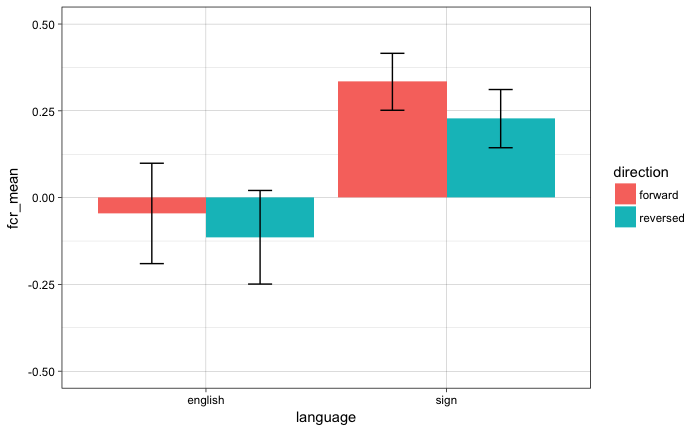

```r
data_mid_error_child <- data_mid %>%
  group_by(language, direction, participant) %>%
  summarise(fcr = mean(fcr)) %>%
  group_by(language, direction) %>%
  summarise(fcr_mean = mean(fcr),
            sd = sd(fcr),
            n = n(),
            se = sd/sqrt(n))
ggplot(data_mid_error_child, aes(x = language, y = fcr_mean, fill = direction)) +
  geom_bar(stat = "identity", position = position_dodge()) +
  geom_errorbar(aes(ymin = fcr_mean-se, ymax = fcr_mean+se), position = position_dodge(0.9), width = 0.2) +
  scale_y_continuous(limits = c(-0.5, 0.5)) +
  theme_linedraw()
```

Let’s go ahead and plot boxplots. FaceChest Ratio here.

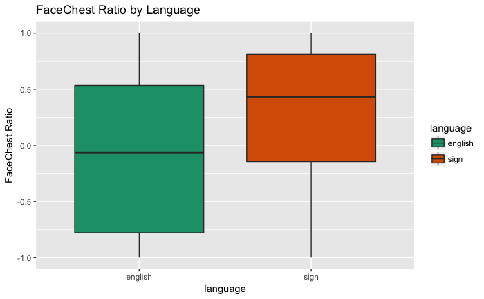

```r
ggplot(data_mid, aes(x = language, y = fcr, fill = language)) + geom_boxplot() + scale_fill_brewer(palette = "Dark2") + ylab("FaceChest Ratio") + ggtitle("FaceChest Ratio by Language")
```

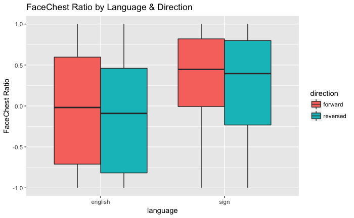

```r
ggplot(data_mid, aes(x = language, y = fcr, fill = direction)) + geom_boxplot() + ylab("FaceChest Ratio") + ggtitle("FaceChest Ratio by Language & Direction")
```

And Middle-Middle FaceChest Ratio here.

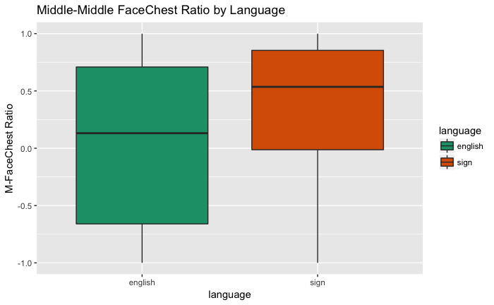

```r
ggplot(data_mid, aes(x = language, y = mfcr, fill = language)) + geom_boxplot() + scale_fill_brewer(palette = "Dark2") + ylab("M-FaceChest Ratio") + ggtitle("Middle-Middle FaceChest Ratio by Language")
```

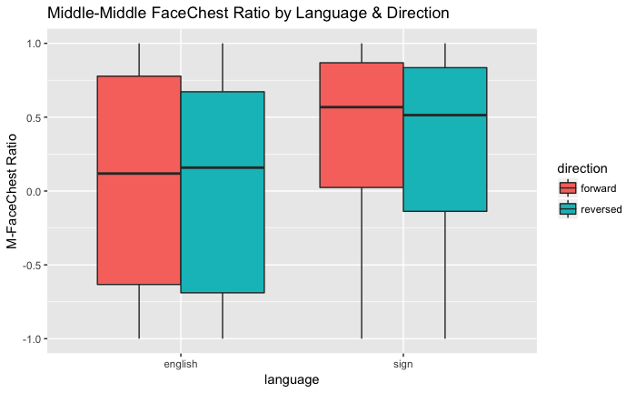

```r
ggplot(data_mid, aes(x = language, y = mfcr, fill = direction)) + geom_boxplot() + ylab("M-FaceChest Ratio") + ggtitle("Middle-Middle FaceChest Ratio by Language & Direction")
```

# Could Age be Polynomial?

I graphed age using a polynomial scale (^2, parabolic) and there definitely seems to be something there. I’m not sure how to work with these, though, so putting it off for a bit later. See below:

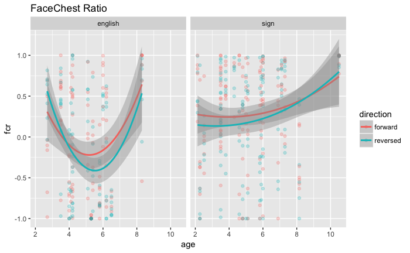

```r
ggplot(data_mid, aes(x = age, y = fcr, color = direction)) + geom_point(alpha = 0.25) +
  geom_smooth(method = "loess", span = 5) + facet_wrap("language") + ggtitle("FaceChest Ratio")
```

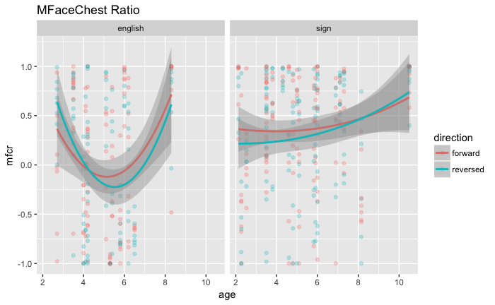

```r
ggplot(data_mid, aes(x = age, y = mfcr, color = direction)) + geom_point(alpha = 0.25) +
  geom_smooth(method = "loess", span = 5) + facet_wrap("language") + ggtitle("MFaceChest Ratio")
```

# How Young Can We Go?

```r
data_young <- data_mid %>%
  ungroup() %>%
  filter(age < 4)
data_young %>% select(participant, language) %>% distinct() %>% count(language)
```

| language | n |
| --- | --- |
| english | 3 |
| sign | 7 |

```r
fcr_lmm_young <- lmer(fcr ~ direction * language + (1|story) + (1|participant), data = data_young)
summary(fcr_lmm_young)
```

```
Linear mixed model fit by REML t-tests use Satterthwaite approximations to degrees of freedom [lmerMod]
Formula: fcr ~ direction * language + (1 | story) + (1 | participant)
   Data: data_young

REML criterion at convergence: 190.9

Scaled residuals:
     Min       1Q   Median       3Q      Max
-2.94201 -0.49344  0.09332  0.61331  2.77887

Random effects:
 Groups      Name        Variance Std.Dev.
 participant (Intercept) 0.11488  0.3389
 story       (Intercept) 0.01097  0.1047
 Residual                0.19981  0.4470
Number of obs: 131, groups:  participant, 10; story, 8

Fixed effects:
                                Estimate Std. Error        df t value Pr(>|t|)
(Intercept)                      0.25098    0.22310  10.44000   1.125    0.286
directionreversed                0.07022    0.14271 115.28000   0.492    0.624
languagesign                     0.06706    0.26277   9.94000   0.255    0.804
directionreversed:languagesign  -0.23867    0.17058 112.48000  -1.399    0.165

Correlation of Fixed Effects:
            (Intr) drctnr lnggsg
dirctnrvrsd -0.318
languagesgn -0.823  0.264
drctnrvrsd:  0.260 -0.819 -0.319
```